# Analyzing Individual BGG Users

Phil Henrickson

2022-01-02

# **Holtey’s** BoardGameGeek Collection

This notebook contains a set of analyses for the selected user’s boardgamegeek collection. The bulk of the analysis is focused on building a user-specific predictive model to predict the games that Holtey is likely to own. This enables to ask questions like, based on the games the user currently owns, what games are a good fit for their collection? What upcoming games are they likely to purchase?

This analysis is based on data from BoardGameGeek that was last updated on **2021-12-20.**

# 1 Collection Overview

We can look at a basic description of the number of games that the user owns, has rated, has previously owned, etc.

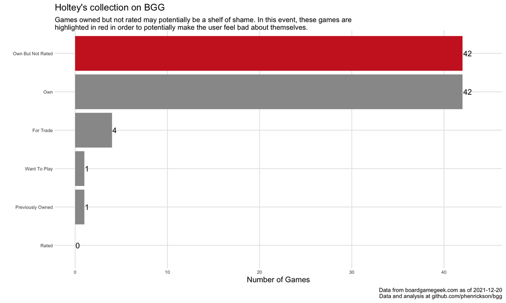

What years has the user owned/rated games from? While we can’t see when a user added or removed a game from their collection, we can look at their collection by the years in which their games were published.

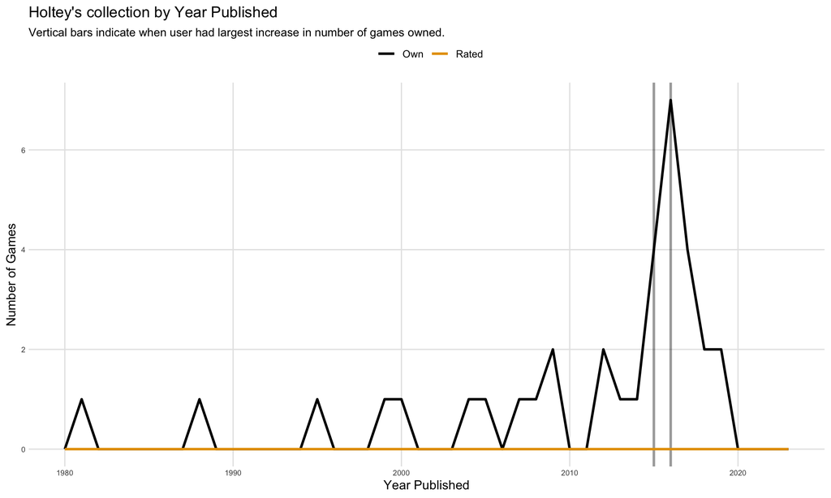

## 1.1 What types of games does Holtey own?

We can look at the most frequent types of categories, mechanics, designers, and artists that appear in a user’s collection.

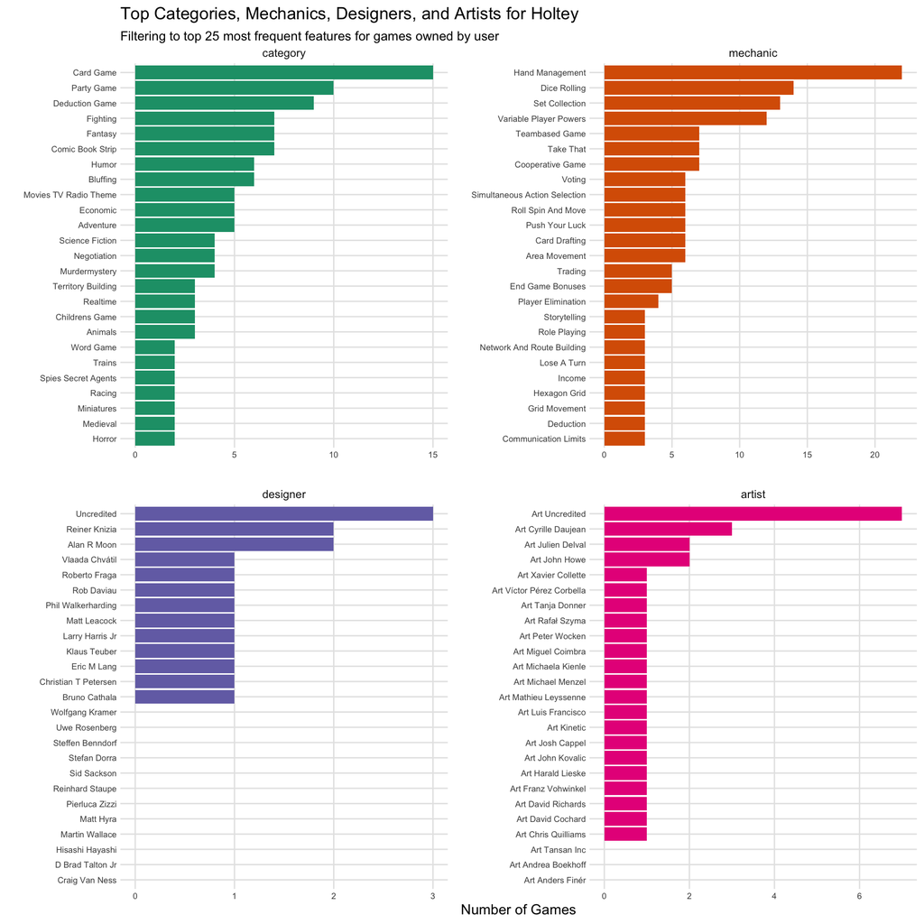

# 2 Modeling **Holtey’s** Collection

| username | dataset | period | games_owned | games_rated | games_played |
| --- | --- | --- | --- | --- | --- |
| Holtey | training | published before 2018 | 38 | 0 | 39 |
| Holtey | test | published 2018 or later | 4 | 0 | 4 |

There are two main (binary) outcomes we will be modeling for the user.

The first, **own** refers to whether the user currently lists a game as owned in their collection. The second, **played** refers to whether the user currently owns, has rated, or previously owned a game. This means the latter will generally have a larger list of games, but may still be a useful category to examine for people who play lots of games without necessarily owning them.

We will train predictive models to learn the probability that the user will own or play individual games based on their features.

## 2.1 Coefficients for Holtey

We can examine coefficients from the trained modes, which are penalized logistic regressions fit to our two main outcomes. Positive values indicate that a feature increases a user’s probabilility of owning/rating a game, while negative values indicate a feature decreases the probability.

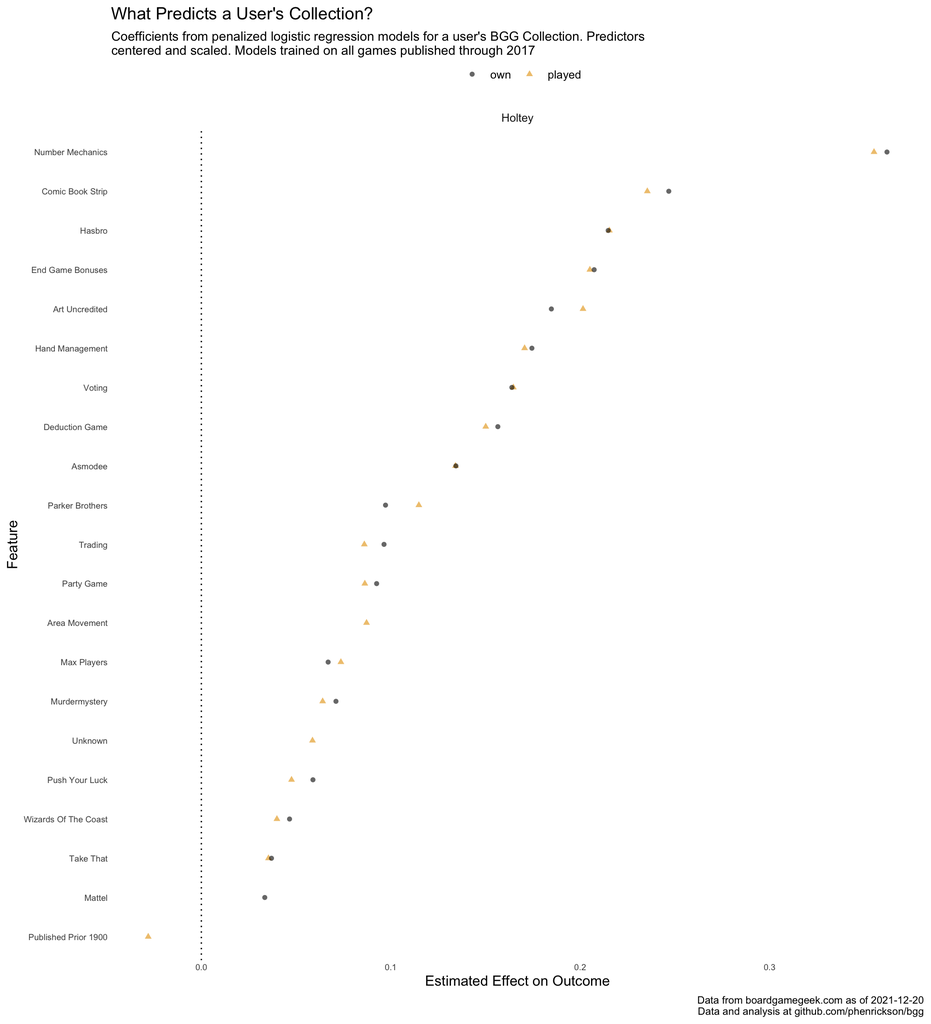

## 2.2 Visualizing Predictors for Holtey’s Collection

Why did the model identify these features? We can make density plots of the important features for predicting whether the user owned a game. Blue indicates the density for games owned by the user, while grey indicates the density for games not owned by the user.

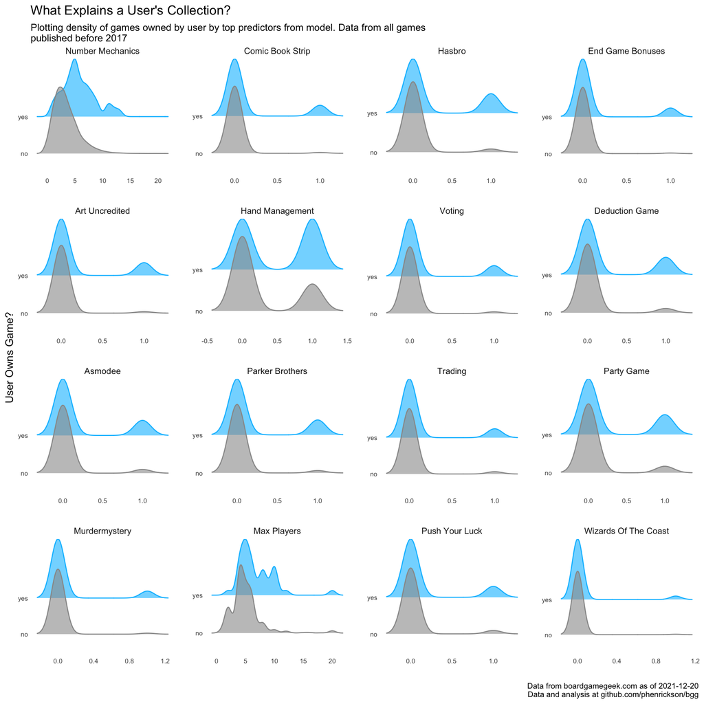

Binary predictors can be difficult to see with this visualization, so we can also directly examine the percentage of games in a user’s collection with a predictor vs the percentage of all games with that predictor.

| username | Feature | % of Games with Feature In_Collection | % of Games with Feature All_Games | Ratio |
| --- | --- | --- | --- | --- |
| Holtey | End Game Bonuses | 13.2% | 0.9% | 14.5 |
| Holtey | Comic Book Strip | 15.8% | 1.2% | 12.9 |
| Holtey | Unknown | 13.2% | 1.7% | 7.8 |
| Holtey | Communication Limits | 5.3% | 0.7% | 7.6 |
| Holtey | Wizards Of The Coast | 5.3% | 0.7% | 7.5 |
| Holtey | Murdermystery | 10.5% | 1.6% | 6.8 |
| Holtey | Voting | 15.8% | 2.5% | 6.4 |
| Holtey | Parker Brothers | 21.1% | 3.4% | 6.3 |
| Holtey | Hasbro | 26.3% | 4.4% | 6.0 |
| Holtey | Mattel | 7.9% | 1.4% | 5.6 |
| Holtey | Selfpublished | 7.9% | 1.5% | 5.3 |
| Holtey | Asmodee | 21.1% | 5.2% | 4.1 |
| Holtey | Deduction Game | 23.7% | 5.9% | 4.0 |
| Holtey | Trading | 13.2% | 3.4% | 3.9 |
| Holtey | Push Your Luck | 15.8% | 5.0% | 3.2 |
| Holtey | Take That | 18.4% | 5.9% | 3.1 |
| Holtey | Party Game | 26.3% | 8.6% | 3.0 |
| Holtey | Word Game | 5.3% | 1.8% | 2.9 |
| Holtey | Negotiation | 10.5% | 3.9% | 2.7 |
| Holtey | Humor | 15.8% | 6.1% | 2.6 |
| Holtey | Area Movement | 15.8% | 6.5% | 2.4 |
| Holtey | Simultaneous Action Selection | 15.8% | 7.4% | 2.1 |
| Holtey | Hand Management | 50.0% | 26.5% | 1.9 |
| Holtey | Horror | 5.3% | 3.7% | 1.4 |
| Holtey | Published Prior 1900 | 0.0% | 1.0% | 0.0 |

# 3 Assess Model’s Performance on Training Set

Before predicting games in upcoming years, we can examine how well the model did and what games it liked in the training set. In this case, we used resampling techniques (cross validation) to ensure that the model had not seen a game before making its predictions.

## 3.1 Separation Plot

An easy way to examine the performance of classification model is to view a separation plot. We plot the predicted probabilities from the model for every game (from resampling) from lowest to highest. We then overlay a blue line for any game that the user does own. A good classifier is one that is able to *separate* the blue (games owned by the user) from the white (games not owned by the user), with most of the blue occurring at the highest probabilities (right side of the chart).

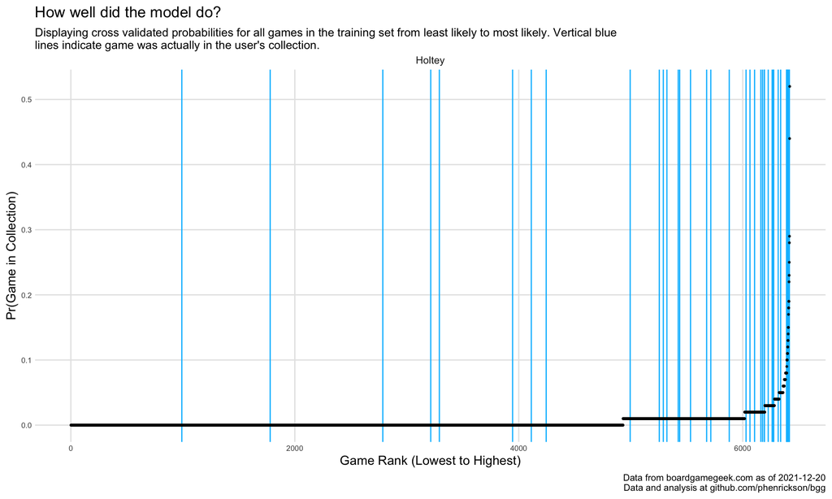

## 3.2 Top Games for **Holtey** from Training Set

We can display this information in table form, displaying the 100 games with the highest probability of ownership, adding a blue line when the user does own the game.

| username | yearpublished | game_id | name | pred_played | pred_own | actual_played | actual_own |
| --- | --- | --- | --- | --- | --- | --- | --- |
| Holtey | 1900 | 2136 | Pachisi | 0.38 | 0.52 | 0 | 0 |
| Holtey | 1988 | 3845 | Yahtzee Jr. | 0.72 | 0.44 | 0 | 0 |
| Holtey | 1959 | 7688 | Memory | 0.36 | 0.29 | 0 | 0 |
| Holtey | 1956 | 2243 | Yahtzee | 0.41 | 0.28 | 1 | 1 |
| Holtey | 1948 | 320 | Scrabble | 0.25 | 0.25 | 1 | 1 |
| Holtey | 1900 | 2083 | Checkers | 0.11 | 0.23 | 0 | 0 |
| Holtey | 2015 | 172242 | Exploding Kittens: NSFW Deck | 0.33 | 0.22 | 0 | 0 |
| Holtey | 2016 | 176083 | Hit Z Road | 0.03 | 0.19 | 0 | 0 |
| Holtey | 1986 | 925 | Werewolf | 0.11 | 0.19 | 0 | 0 |
| Holtey | 2014 | 164265 | Witness | 0.47 | 0.18 | 0 | 0 |
| Holtey | 2005 | 18258 | Mission: Red Planet | 0.13 | 0.18 | 0 | 0 |
| Holtey | 2014 | 157354 | Five Tribes | 0.11 | 0.17 | 0 | 0 |
| Holtey | 1949 | 1294 | Clue | 0.24 | 0.15 | 1 | 1 |
| Holtey | 1900 | 45 | Perudo | 0.22 | 0.15 | 0 | 0 |
| Holtey | 2014 | 152241 | Ultimate Werewolf | 0.03 | 0.14 | 0 | 0 |
| Holtey | 2010 | 62219 | Dominant Species | 0.19 | 0.13 | 0 | 0 |
| Holtey | 1971 | 2223 | UNO | 0.08 | 0.13 | 1 | 1 |
| Holtey | 2017 | 174430 | Gloomhaven | 0.07 | 0.12 | 0 | 0 |
| Holtey | 2012 | 122515 | Keyflower | 0.16 | 0.12 | 0 | 0 |
| Holtey | 2010 | 73439 | Troyes | 0.16 | 0.11 | 0 | 0 |
| Holtey | 2017 | 220774 | Codenames: Marvel | 0.13 | 0.11 | 0 | 0 |
| Holtey | 2016 | 193037 | Dead of Winter: The Long Night | 0.15 | 0.11 | 0 | 0 |
| Holtey | 1900 | 171 | Chess | 0.16 | 0.10 | 0 | 0 |
| Holtey | 2011 | 70919 | Takenoko | 0.16 | 0.10 | 0 | 0 |
| Holtey | 2005 | 14996 | Ticket to Ride: Europe | 0.02 | 0.10 | 0 | 0 |
| Holtey | 2014 | 150376 | Dead of Winter: A Crossroads Game | 0.05 | 0.10 | 1 | 1 |
| Holtey | 1900 | 7316 | Bingo | 0.04 | 0.09 | 0 | 0 |
| Holtey | 1931 | 2425 | Battleship | 0.09 | 0.08 | 0 | 0 |
| Holtey | 2013 | 52461 | Legacy: The Testament of Duke de Crecy | 0.04 | 0.08 | 0 | 0 |
| Holtey | 2015 | 182874 | Grand Austria Hotel | 0.10 | 0.08 | 0 | 0 |

[output cut: 70 more lines]

We can also more formally assess how well the model did in resampling by looking at the area under the receiver operating characteristic. A perfect model would receive a score of 1, while a model that cannot predict the outcome will default to a score of 0.5. The extent to which something is a *good* score depends on the setting, but generally anything in the .8 to .9 range is very good while the .7 to .8 range is perfectly acceptable.

| username | outcome_type | .metric | .estimator | .estimate |
| --- | --- | --- | --- | --- |
| Holtey | own | roc_auc | binary | 0.852 |
| Holtey | played | roc_auc | binary | 0.857 |

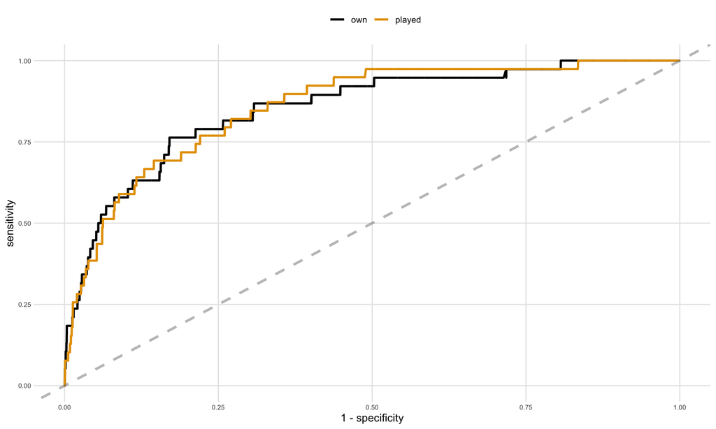

Another way to think about the model performance is to view its lift, or its ability to detect the positive outcomes over that of a null model. High lift indicates the model can much more quickly find all of the positive outcomes (in this case, games owned or played by the user), while a model with no lift is no better than random guessing.

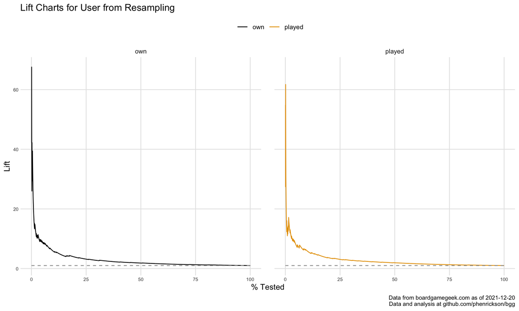

## 3.3 Most and Least Likely Games

What games does the model think Holtey is **most likely to own** that are **not** in their collection?

| username | yearpublished | game_id | name | pred_own | actual_own |
| --- | --- | --- | --- | --- | --- |
| Holtey | 1900 | 2136 | Pachisi | 0.52 | 0 |
| Holtey | 1988 | 3845 | Yahtzee Jr. | 0.44 | 0 |
| Holtey | 1959 | 7688 | Memory | 0.29 | 0 |
| Holtey | 1900 | 2083 | Checkers | 0.23 | 0 |
| Holtey | 2015 | 172242 | Exploding Kittens: NSFW Deck | 0.22 | 0 |

What games does the model think Holtey is **least likely to own** that **are** in their collection?

| username | yearpublished | game_id | name | pred_own | actual_own |
| --- | --- | --- | --- | --- | --- |
| Holtey | 2015 | 172287 | Champions of Midgard | 0 | 1 |
| Holtey | 2015 | 175621 | Epic Card Game | 0 | 1 |
| Holtey | 2016 | 198773 | Codenames: Pictures | 0 | 1 |
| Holtey | 2007 | 28023 | Jamaica | 0 | 1 |
| Holtey | 2017 | 228660 | Betrayal at Baldur's Gate | 0 | 1 |

## 3.4 Top Games by Year

Top 25 games most likely to be owned by the user in each year, highlighting in blue the games that the user has owned/played.

| rank | 2009 | 2010 | 2011 | 2012 | 2013 | 2014 | 2015 | 2016 | 2017 |
| --- | --- | --- | --- | --- | --- | --- | --- | --- | --- |
| 1 | The Werewolves of Miller's Hollow: The Village | Dominant Species | Takenoko | Keyflower | Legacy: The Testament of Duke de Crecy | Witness | Exploding Kittens: NSFW Deck | Hit Z Road | Gloomhaven |
| 2 | Monopoly City | Troyes | Munchkin Axe Cop | Il Vecchio | Corto | Five Tribes | Grand Austria Hotel | Dead of Winter: The Long Night | Codenames: Marvel |
| 3 | The Resistance | Trivial Pursuit: Bet You Know It | Alcatraz: The Scapegoat | Terra Mystica | LEADERS: The Combined Strategy Game | Ultimate Werewolf | Unusual Suspects | Yokohama | Exploding Kittens: Party Pack |
| 4 | Shipyard | Ultimate Werewolf: Compact Edition | Penny Arcade: The Game – Gamers vs. Evil | Targi | Sushi Go! | Dead of Winter: A Crossroads Game | Exploding Kittens | Clank!: A Deck-Building Adventure | Paper Tales |
| 5 | Cranium Scribblish | Battle Cry: 150th Civil War Anniversary Edition | Tragedy Looper | Monopoly Millionaire | Batman: Arkham City Escape | Ultimate Werewolf: Deluxe Edition | The Bloody Inn | Avenue | Breaking Bad: The Board Game |
| 6 | Ra: The Dice Game | Earth Reborn | Letters from Whitechapel | Munchkin Conan | Patchistory | Deception: Murder in Hong Kong | X-Men: Mutant Revolution | 13 Days: The Cuban Missile Crisis | Bears vs Babies |
| 7 | NichtLustig: Labor Chaos | Clue Suspect | The Walking Dead: The Board Game | Tokaido | Superfight | Castles of Mad King Ludwig | Bang! The Dice Game: The Walking Dead | Islebound | Zombie Tsunami |
| 8 | Axis & Allies Pacific 1940 | Hanabi | Battleship Galaxies | Dungeon Command: Curse of Undeath | Dungeon Command: Blood of Gruumsh | Co-Mix | Salem 1692 | Sushi Go Party! | Photosynthesis |
| 9 | Clue: Secrets & Spies | Cyrano | Discworld: Ankh-Morpork | Penny Arcade: The Game – Rumble in R'lyeh | BANG! The Dice Game | Alchemists | Haspelknecht | Munchkin Marvel | Gaia Project |
| 10 | Hansa Teutonica | Key Market | Fief | Exodus: Proxima Centauri | Ultimate Werewolf: Inquisition | Heroes Wanted | Risk: Europe | Imhotep | Fog of Love |
| 11 | Ratuki | Merchants & Marauders | Black Stories: Funny Death Edition | Clue | Tajemnicze Domostwo | Sons of Anarchy: Men of Mayhem | Far Space Foundry | Simon's Cat Card Game | Azul |
| 12 | Dungeon Twister 2: Prison | Sid Meier's Civilization: The Board Game | Dungeons & Dragons: Wrath of Ashardalon Board Game | Dixit: Journey | Two Rooms and a Boom | Sentinel Tactics: The Flame of Freedom | One Night Revolution | OrganATTACK! | Itchy Feet: the Travel Game |
| 13 | Claustrophobia | 1817 | Sentinels of the Multiverse | Dixit Jinx | The Ravens of Thri Sahashri | Camel Up | 504 | Beyond Baker Street | Calimala |
| 14 | Jaipur | Le Donjon de Naheulbeuk | A Few Acres of Snow | The Resistance: Avalon | Batman: Gotham City Strategy Game | Pack of Heroes | Love Letter: Batman | Burke's Gambit | Munchkin X-Men |
| 15 | Mr. Jack in New York | U-Build Monopoly | Sekigahara: The Unification of Japan | Archipelago | Heroes of Metro City | Sherlock Holmes: Four Investigations | Watson & Holmes | Codenames: Deep Undercover | Secrets |
| 16 | Richard III: The Wars of the Roses | Snake Oil | Ascension: Return of the Fallen | Tzolk'in: The Mayan Calendar | Justice League: Axis of Villains Strategy Game | Black Fleet | One Night Ultimate Werewolf: Daybreak | Insider | The Thing: Infection at Outpost 31 |
| 17 | The Message | Mystery Express | Battleship: Hidden Threat | Smash Up | Sorry! with Fire & Ice Power-ups | Good Cop Bad Cop | One Night Ultimate Vampire | Spyfall 2 | Twilight Imperium: Fourth Edition |
| 18 | Funglish | Commands & Colors: Napoleonics | Streams | One Night Werewolf | Concept | Spyfall | Vs System 2PCG: The Marvel Battles | Joking Hazard | One Night Ultimate Alien |
| 19 | Who Would Win | Labyrinth: The War on Terror, 2001 – ? | Drum Roll | City of Horror | Clue | Pictopia: Disney Edition | Justice League: Hero Dice – Superman | Teenage Mutant Ninja Turtles: Shadows of the Past | Tortuga 1667 |
| 20 | Opera | Heroscape Master Set: Battle for the Underdark | Dungeon Petz | Zombicide | Room 25 | Bucket of Doom | Blood Rage | Pandemic: Reign of Cthulhu | Fate of the Elder Gods |
| 21 | Tobago | Zombiaki II: Attack on Moscow | Gears of War: The Board Game | Libertalia | Bomb Squad | One Night Ultimate Werewolf | Risk: Star Wars Edition | Forged in Steel | Bunny Kingdom |
| 22 | Arcana | Julius Caesar: Caesar, Pompey, and the Roman Civil War | Space Empires: 4X | Space Cadets | Brew Crafters | Spurs: A Tale in the Old West | Justice League: Hero Dice – Batman | The Mysterious Forest | Whitehall Mystery |
| 23 | Crunch: The Game for Utter Bankers | Battles of Westeros | Cave Evil | Coup | A Study in Emerald | DC Comics Deck-Building Game: Forever Evil | Codenames | Batman: The Animated Series Dice Game | Pandemic Legacy: Season 2 |
| 24 | Atlantis | Steel Wolves: The German Submarine Campaign Against Allied Shipping – Vol 1 | Santiago de Cuba | Axis & Allies 1941 | Lewis & Clark: The Expedition | Legendary: A Marvel Deck Building Game – Villains | Zombicide Season 3: Rue Morgue | Escape Room in a Box: The Werewolf Experiment | Scott Pilgrim's Precious Little Card Game |
| 25 | Havana | Zombie Dice | The Ares Project | Legendary: A Marvel Deck Building Game | Dungeon Twister: The Card Game | Onward to Venus | Mysterium | Escape the Room: Secret of Dr. Gravely's Retreat | DC Comics Deck-Building Game: Confrontations |

## 3.5 Interactive Predictions from Resampling

Interactive table for predictions from resampling.

|  | username | yearpublished | rank | game_id | name | pred_played | pred_own | actual_played | actual_own |
| --- | --- | --- | --- | --- | --- | --- | --- | --- | --- |
| 1 | Holtey | 1900 | 1 | 2136 | Pachisi | 0.38 | 0.52 | 0 | 0 |
| 2 | Holtey | 1900 | 6 | 2083 | Checkers | 0.11 | 0.23 | 0 | 0 |
| 3 | Holtey | 1900 | 14 | 45 | Perudo | 0.22 | 0.15 | 0 | 0 |
| 4 | Holtey | 1900 | 23 | 171 | Chess | 0.16 | 0.1 | 0 | 0 |
| 5 | Holtey | 1900 | 27 | 7316 | Bingo | 0.04 | 0.09 | 0 | 0 |
| 6 | Holtey | 1900 | 35 | 10799 | Old Maid | 0.04 | 0.08 | 0 | 0 |
| 7 | Holtey | 1900 | 82 | 15878 | Rummy | 0.03 | 0.05 | 0 | 0 |
| 8 | Holtey | 1900 | 88 | 4792 | Tiddledy Winks | 0.04 | 0.05 | 0 | 0 |
| 9 | Holtey | 1900 | 124 | 5432 | Chutes and Ladders | 0.05 | 0.04 | 0 | 0 |
| 10 | Holtey | 1900 | 127 | 11670 | The Game of Authors | 0.03 | 0.04 | 0 | 0 |

[output cut: 6410 more lines]

# 4 Validating the Model on 2018

How well did a model trained on a user’s collection through 2017 perform in predicting games for the user from 2018?

| username | outcome_type | yearpublished | .metric | .estimator | .estimate |
| --- | --- | --- | --- | --- | --- |
| Holtey | own | 2018 | roc_auc | binary | 0.861 |
| Holtey | played | 2018 | roc_auc | binary | 0.864 |

Table of top 25 games from 2018, highlighting games that the user owns.

| username | yearpublished | game_id | name | pred_own | pred_played | actual_own | actual_played |
| --- | --- | --- | --- | --- | --- | --- | --- |
| Holtey | 2018 | 205896 | Rising Sun | 0.28 | 0.32 | 0 | 0 |
| Holtey | 2018 | 221371 | DC Spyfall | 0.14 | 0.12 | 0 | 0 |
| Holtey | 2018 | 244711 | Newton | 0.10 | 0.09 | 0 | 0 |
| Holtey | 2018 | 256877 | Hail Hydra | 0.10 | 0.09 | 0 | 0 |
| Holtey | 2018 | 232405 | Western Legends | 0.09 | 0.11 | 0 | 0 |
| Holtey | 2018 | 222219 | Kero | 0.08 | 0.08 | 0 | 0 |
| Holtey | 2018 | 256226 | Azul: Stained Glass of Sintra | 0.06 | 0.06 | 0 | 0 |
| Holtey | 2018 | 199792 | Everdell | 0.05 | 0.04 | 0 | 0 |
| Holtey | 2018 | 245928 | Pax Emancipation | 0.05 | 0.05 | 0 | 0 |
| Holtey | 2018 | 247763 | Underwater Cities | 0.05 | 0.04 | 0 | 0 |
| Holtey | 2018 | 192296 | The Pirate Republic | 0.04 | 0.05 | 0 | 0 |
| Holtey | 2018 | 204286 | Big Trouble in Little China: The Game | 0.04 | 0.04 | 0 | 0 |
| Holtey | 2018 | 244331 | Blue Lagoon | 0.04 | 0.04 | 0 | 0 |
| Holtey | 2018 | 246297 | Shadows: Amsterdam | 0.04 | 0.04 | 0 | 0 |
| Holtey | 2018 | 252693 | Batman: The Animated Series – Gotham City Under Siege | 0.04 | 0.03 | 0 | 0 |
| Holtey | 2018 | 258444 | Gingerbread House | 0.04 | 0.04 | 0 | 0 |
| Holtey | 2018 | 214032 | Founders of Gloomhaven | 0.03 | 0.03 | 0 | 0 |
| Holtey | 2018 | 245422 | Werewords Deluxe Edition | 0.03 | 0.03 | 0 | 0 |
| Holtey | 2018 | 245638 | Coimbra | 0.03 | 0.03 | 0 | 0 |
| Holtey | 2018 | 252197 | One Week Ultimate Werewolf | 0.03 | 0.03 | 0 | 0 |
| Holtey | 2018 | 252776 | Muse: Awakenings | 0.03 | 0.03 | 0 | 0 |
| Holtey | 2018 | 253618 | 5-Minute Marvel | 0.03 | 0.03 | 1 | 1 |
| Holtey | 2018 | 257321 | Gen7: A Crossroads Game | 0.03 | 0.03 | 0 | 0 |
| Holtey | 2018 | 170604 | Renegade | 0.02 | 0.02 | 0 | 0 |
| Holtey | 2018 | 201509 | Dead Man's Doubloons | 0.02 | 0.02 | 0 | 0 |

# 5 Predicting Upcoming Games (2018 and On) for **Holtey**

Examine the top games for the test set.

| username | yearpublished | game_id | name | rank | own | played |
| --- | --- | --- | --- | --- | --- | --- |
| Holtey | 2018 | 205896 | Rising Sun | 1 | 0.28 | 0.32 |
| Holtey | 2018 | 221371 | DC Spyfall | 2 | 0.14 | 0.12 |
| Holtey | 2018 | 244711 | Newton | 3 | 0.10 | 0.09 |
| Holtey | 2018 | 256877 | Hail Hydra | 4 | 0.10 | 0.09 |
| Holtey | 2018 | 232405 | Western Legends | 5 | 0.09 | 0.11 |
| Holtey | 2018 | 222219 | Kero | 6 | 0.08 | 0.08 |
| Holtey | 2018 | 256226 | Azul: Stained Glass of Sintra | 7 | 0.06 | 0.06 |
| Holtey | 2018 | 199792 | Everdell | 8 | 0.05 | 0.04 |
| Holtey | 2018 | 247763 | Underwater Cities | 9 | 0.05 | 0.04 |
| Holtey | 2018 | 245928 | Pax Emancipation | 10 | 0.05 | 0.05 |
| Holtey | 2018 | 252693 | Batman: The Animated Series – Gotham City Under Siege | 11 | 0.04 | 0.03 |
| Holtey | 2018 | 204286 | Big Trouble in Little China: The Game | 12 | 0.04 | 0.04 |
| Holtey | 2018 | 192296 | The Pirate Republic | 13 | 0.04 | 0.05 |
| Holtey | 2018 | 258444 | Gingerbread House | 14 | 0.04 | 0.04 |
| Holtey | 2018 | 246297 | Shadows: Amsterdam | 15 | 0.04 | 0.04 |
| Holtey | 2018 | 244331 | Blue Lagoon | 16 | 0.04 | 0.04 |
| Holtey | 2018 | 252776 | Muse: Awakenings | 17 | 0.03 | 0.03 |
| Holtey | 2018 | 214032 | Founders of Gloomhaven | 18 | 0.03 | 0.03 |
| Holtey | 2018 | 245422 | Werewords Deluxe Edition | 19 | 0.03 | 0.03 |
| Holtey | 2018 | 257321 | Gen7: A Crossroads Game | 20 | 0.03 | 0.03 |
| Holtey | 2018 | 245638 | Coimbra | 21 | 0.03 | 0.03 |
| Holtey | 2018 | 253618 | 5-Minute Marvel | 22 | 0.03 | 0.03 |
| Holtey | 2018 | 252197 | One Week Ultimate Werewolf | 23 | 0.03 | 0.03 |
| Holtey | 2018 | 247436 | Sherlock: The Tomb of the Archaeologist | 24 | 0.02 | 0.02 |
| Holtey | 2018 | 250779 | Sherlock: Death on the 4th of July | 25 | 0.02 | 0.02 |
| Holtey | 2019 | 276025 | Maracaibo | 1 | 0.17 | 0.16 |
| Holtey | 2019 | 270971 | Era: Medieval Age | 2 | 0.17 | 0.15 |
| Holtey | 2019 | 266507 | Clank!: Legacy – Acquisitions Incorporated | 3 | 0.17 | 0.16 |
| Holtey | 2019 | 257066 | Sierra West | 4 | 0.11 | 0.11 |
| Holtey | 2019 | 285774 | Marvel Champions: The Card Game | 5 | 0.09 | 0.08 |
| Holtey | 2019 | 283863 | The Magnificent | 6 | 0.09 | 0.09 |
| Holtey | 2019 | 271324 | It's a Wonderful World | 7 | 0.06 | 0.05 |
| Holtey | 2019 | 264982 | Coloma | 8 | 0.06 | 0.05 |
| Holtey | 2019 | 260710 | Amul | 9 | 0.06 | 0.06 |
| Holtey | 2019 | 265736 | Tiny Towns | 10 | 0.06 | 0.06 |
| Holtey | 2019 | 275034 | Judge Dredd: Helter Skelter | 11 | 0.05 | 0.05 |
| Holtey | 2019 | 266192 | Wingspan | 12 | 0.05 | 0.05 |
| Holtey | 2019 | 222514 | Batman: Gotham City Chronicles | 13 | 0.05 | 0.06 |
| Holtey | 2019 | 251247 | Barrage | 14 | 0.05 | 0.05 |
| Holtey | 2019 | 256730 | Pipeline | 15 | 0.04 | 0.04 |
| Holtey | 2019 | 280136 | Paranormal Detectives | 16 | 0.04 | 0.03 |
| Holtey | 2019 | 253635 | Ragusa | 17 | 0.04 | 0.04 |
| Holtey | 2019 | 280480 | Crystal Palace | 18 | 0.04 | 0.04 |
| Holtey | 2019 | 264220 | Tainted Grail: The Fall of Avalon | 19 | 0.03 | 0.03 |
| Holtey | 2019 | 273477 | Obscurio | 20 | 0.03 | 0.03 |
| Holtey | 2019 | 240567 | Chocolate Factory | 21 | 0.03 | 0.03 |
| Holtey | 2019 | 270673 | Silver & Gold | 22 | 0.03 | 0.03 |
| Holtey | 2019 | 287954 | Azul: Summer Pavilion | 23 | 0.03 | 0.03 |
| Holtey | 2019 | 275010 | De Vulgari Eloquentia: Deluxe Edition | 24 | 0.03 | 0.03 |
| Holtey | 2019 | 233868 | HATE | 25 | 0.03 | 0.03 |
| Holtey | 2020 | 256317 | Guild Master | 1 | 0.35 | 0.32 |
| Holtey | 2020 | 184267 | On Mars | 2 | 0.17 | 0.16 |
| Holtey | 2020 | 316927 | Sweet Existence: A Strange Planet Card Game | 3 | 0.09 | 0.08 |
| Holtey | 2020 | 304285 | Infinity Gauntlet: A Love Letter Game | 4 | 0.09 | 0.08 |
| Holtey | 2020 | 302840 | Carcata | 5 | 0.08 | 0.09 |
| Holtey | 2020 | 300322 | Hallertau | 6 | 0.08 | 0.08 |
| Holtey | 2020 | 257145 | Teenage Mutant Ninja Turtles Adventures: City Fall | 7 | 0.07 | 0.06 |
| Holtey | 2020 | 291457 | Gloomhaven: Jaws of the Lion | 8 | 0.06 | 0.06 |
| Holtey | 2020 | 263192 | Teenage Mutant Ninja Turtles Adventures: Change is Constant | 9 | 0.06 | 0.05 |
| Holtey | 2020 | 296151 | Viscounts of the West Kingdom | 10 | 0.06 | 0.06 |
| Holtey | 2020 | 313698 | Monster Expedition | 11 | 0.05 | 0.04 |
| Holtey | 2020 | 313817 | Hello Neighbor: The Secret Neighbor Party Game | 12 | 0.05 | 0.04 |
| Holtey | 2020 | 302310 | Nanaki | 13 | 0.05 | 0.05 |
| Holtey | 2020 | 320819 | Dinner in Paris | 14 | 0.05 | 0.05 |
| Holtey | 2020 | 298371 | Wild Space | 15 | 0.04 | 0.03 |
| Holtey | 2020 | 291874 | Dwergar | 16 | 0.04 | 0.03 |
| Holtey | 2020 | 298047 | Marvel United | 17 | 0.04 | 0.03 |
| Holtey | 2020 | 263085 | Darksiders: The Forbidden Land | 18 | 0.04 | 0.03 |
| Holtey | 2020 | 292333 | Cowboys II: Cowboys & Indians Edition | 19 | 0.04 | 0.04 |
| Holtey | 2020 | 227224 | The Red Cathedral | 20 | 0.04 | 0.04 |
| Holtey | 2020 | 253506 | Versailles 1919 | 21 | 0.04 | 0.04 |
| Holtey | 2020 | 308765 | Praga Caput Regni | 22 | 0.04 | 0.04 |
| Holtey | 2020 | 279537 | The Search for Planet X | 23 | 0.04 | 0.04 |
| Holtey | 2020 | 295687 | Trust Me, I'm a Doctor | 24 | 0.03 | 0.02 |
| Holtey | 2020 | 302336 | Marvel Villainous: Infinite Power | 25 | 0.03 | 0.02 |

## 5.1 Interactive Table for Upcoming Games 2018 and On

|  | username | yearpublished | game_id | name | rank | own | played |
| --- | --- | --- | --- | --- | --- | --- | --- |
| 1 | Holtey | 2020 | 256317 | Guild Master | 1 | 0.35 | 0.32 |
| 2 | Holtey | 2018 | 205896 | Rising Sun | 2 | 0.28 | 0.32 |
| 3 | Holtey | 2019 | 276025 | Maracaibo | 3 | 0.17 | 0.16 |
| 4 | Holtey | 2020 | 184267 | On Mars | 4 | 0.17 | 0.16 |
| 5 | Holtey | 2019 | 270971 | Era: Medieval Age | 5 | 0.17 | 0.15 |
| 6 | Holtey | 2019 | 266507 | Clank!: Legacy – Acquisitions Incorporated | 6 | 0.17 | 0.16 |
| 7 | Holtey | 2018 | 221371 | DC Spyfall | 7 | 0.14 | 0.12 |
| 8 | Holtey | 2019 | 257066 | Sierra West | 8 | 0.11 | 0.11 |
| 9 | Holtey | 2018 | 244711 | Newton | 9 | 0.1 | 0.09 |
| 10 | Holtey | 2018 | 256877 | Hail Hydra | 10 | 0.1 | 0.09 |

[output cut: 1923 more lines]